# Combining factor levels with trees

Bizovi Mihai

10/12/2019

It is almost always hard to work with **high cardinality** features such as zip codes. Deep learning practitioners have the concept of **embeddings** coming to the rescue sometimes, but that doesn’t save the modeler if there are not enough samples to handle such a dimensionality. Recent advances, such as the brilliant **Catboost** are found to work well empirically, but what to do when the task is one of inference? A rigorous way would be to use (Bayesian) Hierarchical Models and pooling, but it is hard and time-consuming.

> “In practice, it’s like “you have the zip code”, but the underlying true variable is “urban/rural” (in the context of spatial factors, it would be better to incorporate the fact that some levels are “neighboors”). If you do not merge them, you will clearly overfit!" - comment by A. Carpentier

An interesting [blog post](https://freakonometrics.hypotheses.org/58446) by A. Carpentier is about combining factor levels with trees. This is an example of post-hoc testing to extract the hierarchical structure of factors. Here are some additional resources to consider, if you want to experiment with this approach:

- The original [blog post](https://freakonometrics.hypotheses.org/55451) on combining factors with t-tests
- The factorMerger [package website](https://modeloriented.github.io/factorMerger/articles/factorMerger.html)
- The [paper](https://arxiv.org/pdf/1709.04412.pdf) for the Journal of Statistical Software

### Getting started

```r
# install the package manager
if (!require("pacman")) {
  install.packages("pacman")
}

# load the packages
pacman::p_load(factorMerger, tidyverse, rpart, rpart.plot)
```

```r
set.seed(1)

# simulate the dataset
n  <- 200
x1 <- runif(n)
x2 <- runif(n)

# a regression with a factor variable and a continuous one
y <- 1 + 2*x1 - x2 + rnorm(n, 0, 0.2)
labs <- sample(LETTERS[1:10])

df <- tibble(
  y = y, x1 = x1,
  x2 = cut(x2, breaks = c(-1, .05, .1, .2, .35, .4, .55, .65, .8, .9, 2),
           labels = labs)
)
head(df) %>% knitr::kable()
```

| y | x1 | x2 |
| --- | --- | --- |
| 1.3453895 | 0.2655087 | F |
| 1.8633772 | 0.3721239 | F |
| 1.9462276 | 0.5728534 | D |
| 2.4812834 | 0.9082078 | F |
| 0.7651484 | 0.2016819 | H |
| 2.7777356 | 0.8983897 | D |

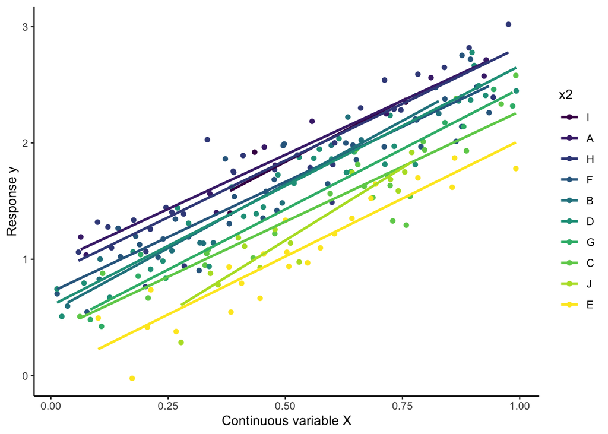

```r
df %>% ggplot(aes(x = x1, y = y, color = x2)) +
  geom_point() +
  stat_smooth(method="lm", se=FALSE) +
  theme_classic() +
  scale_color_viridis_d() +
  labs(x = "Continuous variable X", y = "Response y")
```

```r
summary(lm(y~x1+x2,data=df))
```

```
##
## Call:
## lm(formula = y ~ x1 + x2, data = df)
##
## Residuals:
##      Min       1Q   Median       3Q      Max
## -0.55805 -0.12477 -0.00275  0.13310  0.50980
##
## Coefficients:
##              Estimate Std. Error t value Pr(>|t|)
## (Intercept)  0.843802   0.119655   7.052 3.23e-11 ***
## x1           1.992878   0.053838  37.016  < 2e-16 ***
## x2A          0.055500   0.131173   0.423   0.6727
## x2H          0.009293   0.121626   0.076   0.9392
## x2F         -0.177002   0.121020  -1.463   0.1452
## x2B         -0.218152   0.130192  -1.676   0.0955 .
## x2D         -0.206970   0.121294  -1.706   0.0896 .
## x2G         -0.407417   0.129999  -3.134   0.0020 **
## x2C         -0.526708   0.123690  -4.258 3.24e-05 ***
## x2J         -0.664281   0.128126  -5.185 5.54e-07 ***
## x2E         -0.816454   0.123625  -6.604 3.94e-10 ***
## ---
## Signif. codes:  0 '***' 0.001 '**' 0.01 '*' 0.05 '.' 0.1 ' ' 1
##
## Residual standard error: 0.2014 on 189 degrees of freedom
## Multiple R-squared:  0.8995, Adjusted R-squared:  0.8942
## F-statistic: 169.1 on 10 and 189 DF,  p-value: < 2.2e-16
```

### Strategies for combining factors

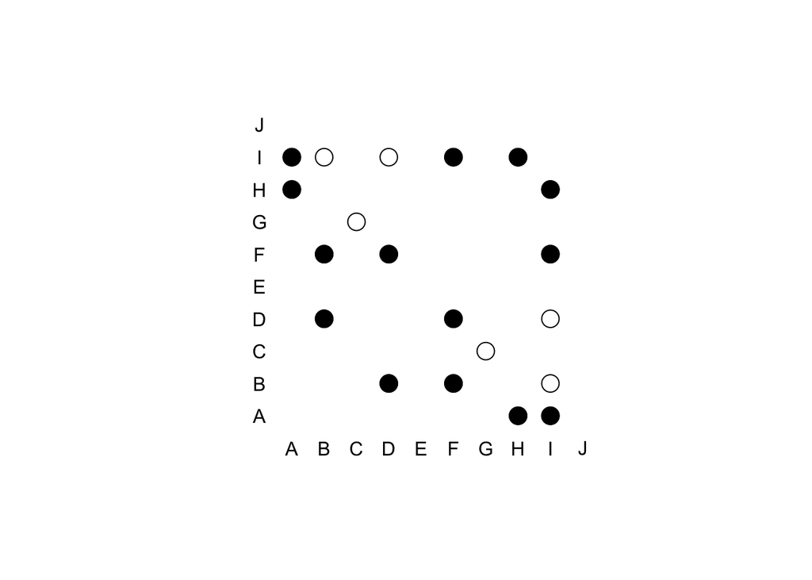

```r
# construct the factor matrix
nr_levels <- nlevels(df$x2)
P <- matrix(NA, nr_levels, nr_levels)
colnames(P) <- LETTERS[1:10]
rownames(P) <- LETTERS[1:10]

# plot an empty matrix
plot(1:nlevels(df$x2), 1:nr_levels, col = "white",
     xlab = "",ylab = "", axes = FALSE, xlim = c(0, 10.5),
     ylim = c(0, 10.5), asp = 1)

# plot the axis labeling
text(1:10, 0, LETTERS[1:10])
text(0, 1:10, LETTERS[1:10])

# iterate for each level
for(i in 1:nr_levels){
  df$x2 <- relevel(df$x2,LETTERS[i])

  # extract the p-value of coefficients, excluding intercept and continuous
  p <- summary(lm(y ~ x1 + x2, data = df))$coefficients[-(1:2), 4]
  names(p) <- substr(names(p),3,3) # extract variable names

  P[LETTERS[i], names(p)] <- p
  p <- P[LETTERS[i], ]

  # add black points with p-value greater than 0.5
  idx <- which(p >= .05)
  points(((1:10))[idx], rep(i, length(idx)), pch=1, cex=2)

  # add black points with p-value greater than 0.5
  idx=which(p >= .1)
  points(((1:10))[idx], rep(i,length(idx)), pch=19, cex=2)
}
```

For a better readability, we can manually define the order of factors. Again, very careful thought is needed when automating this, especially with combining factors (see the pitfalls).

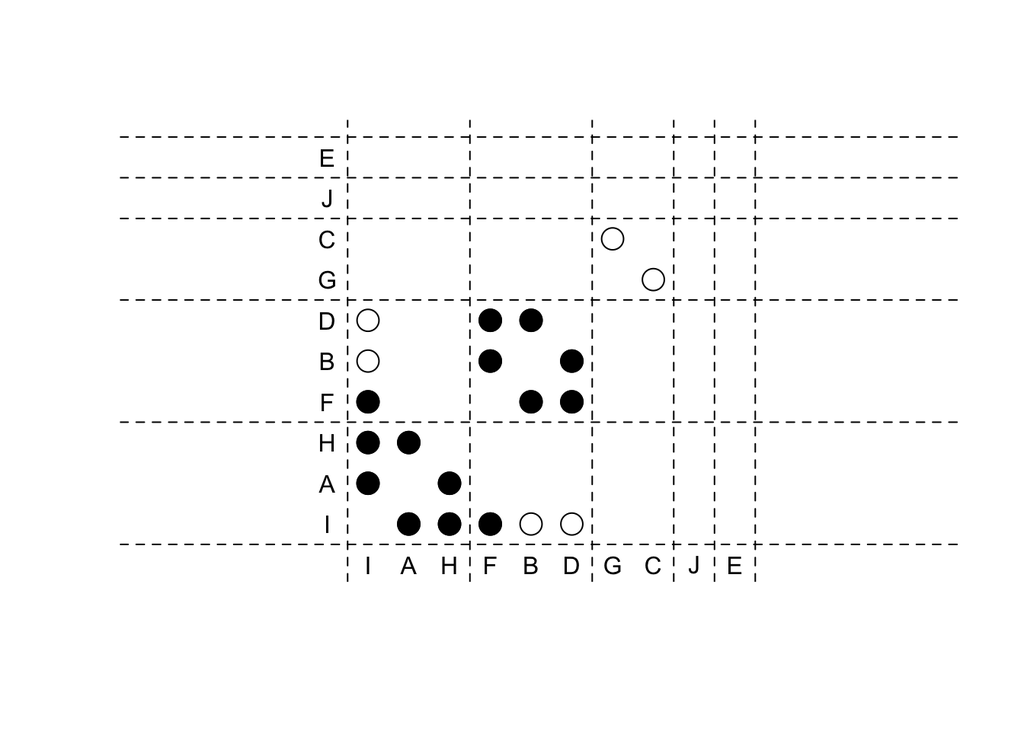

```r
LETTERSord <- c("I","A","H","F","B","D","G","C","J","E")
P <- matrix(NA, nr_levels, nr_levels)
colnames(P) <- LETTERSord
rownames(P) <- LETTERSord
ct <- c(3,3,2,1,1) # cutoffs

# plot the empty, ordered matrix with the cutoffs
plot(1:nr_levels, 1:nr_levels, col="white", xlab="", ylab="",
     axes=FALSE, xlim=c(0,10.5), ylim=c(0,10.5), asp = 1)
abline(v=.5 + c(0, cumsum(ct)), lty=2)
abline(h=.5 + c(0, cumsum(ct)), lty=2)
text(1:10, 0, LETTERSord)
text(0, 1:10, LETTERSord)


for(i in 1:nr_levels){
  df$x2 <- relevel(df$x2, LETTERSord[i])

  # linear regression with testing the factors
  p <- summary(lm(y ~ x1 + x2, data = df))$coefficients[-(1:2),4]
  names(p) <- substr(names(p), 3, 3)

  P[LETTERSord[i], names(p)] <- p
  p <- P[LETTERSord[i], ]

  idx <- which(p >= .05)
  points(((1:10))[idx], rep(i,length(idx)), pch=1, cex=2)

  idx <- which(p >= .1)
  points(((1:10))[idx],rep(i,length(idx)), pch=19, cex=2)
}
```

### Pitfalls

- Post-hoc, multiple testing which should be accounted for
- Information leakage, because we used the value of the target
- An approach similar to what `catboost` is doing could help to mitigate the issue, or a careful data split and methodology when doing these kind of things.

Nonetheless, a decision tree carefully ran on the residual, might suggest factor combinations which can improve the regression. Again, remembering Y. A. Mostafa, we should account for the degrees of freedom used by this investigation, if we are to assess the generalization of the model with combined factors.

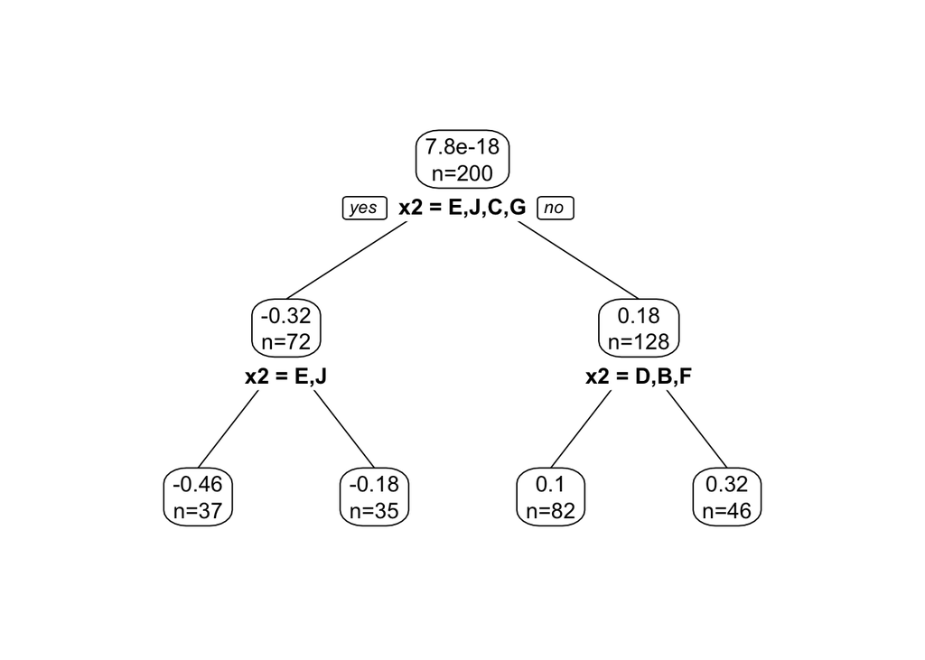

```r
# running a regression tree on the residuals to be explained
# by the categorical variable
df$e <- residuals(lm(y ~ x1, data = df))
tree <- rpart(e ~ x2, data = df)
prp(tree, type = 2, extra = 1)
```

### FactorMerger library

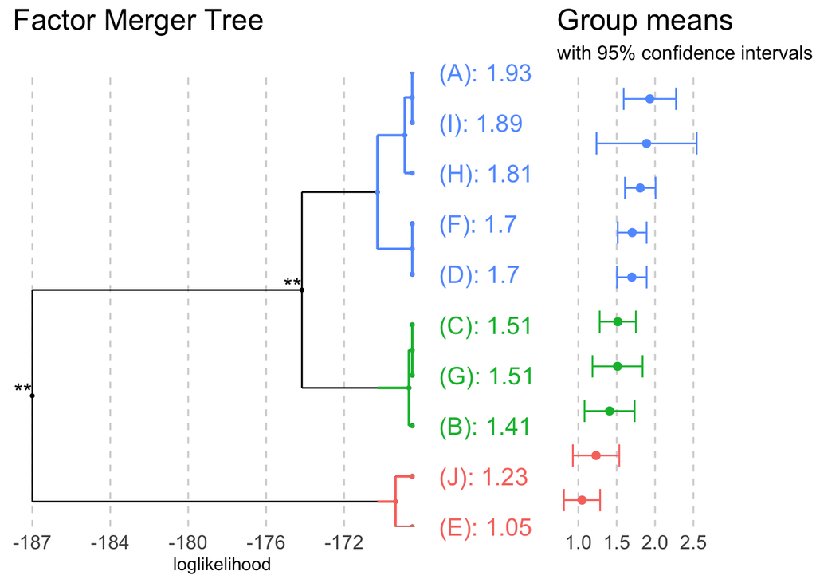

```r
merged_factors <- factorMerger::mergeFactors(
  response = df$y, factor = df$x2, family = "gaussian")
plot(merged_factors, panel = "response" )
```

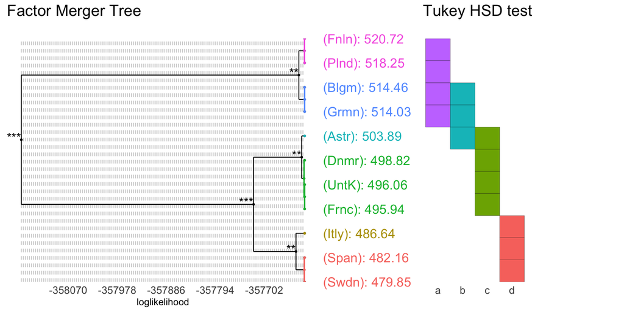

```r
fmAll <- mergeFactors(
 response = pisa2012$math,
 factor = pisa2012$country,
 method = "fast-adaptive",
 family = "gaussian")

plot(fmAll, panel = "response", responsePanel = "tukey")
```

[figure not shown]

```r
plot(fmAll, panel = "response", responsePanel = "profile")
```